# Exercises: Stressor interactions and statistical interactions

Iris Madge Pimentel

2025-06-04

# Introduction and setup

In this exercise, we will learn how to use regression models to analyse stressor interactions. We test for deviations from two multiple-stressor null models: From the simple addition (AD) and multiplicative (MU) null model. We fit generalized linear models (GLMs) and learn which null model aligns with which regression model specification. We will produce conditional plots and marginal effects plots for a closer analysis of detected interactions and we will also take a look at how to use the **marginaleffects** package to analyse stressor interactions if the null model does not align with the best-fitting regression model.

The following R packages are required:

```r
library(tidyverse) # for data handling and plottin
library(DHARMa) # for residual diagnostics in GLMs
library(marginaleffects) # for inference with regression models
library(glmmTMB) # for GLMs with negative binomial regression
library(car) # companion functions to analyse regression models
set.seed(1) # for reproducibility
```

We load in the example data sets used as case studies. One data set will be used to exemplify an interaction analysis for two factorial stressors and the other for a factorial-gradient combination.

```r
df.mesocosms <- read_csv("data/Beermannetal_2018_abundances.csv")
df.simulated<- read_csv("data/simulated_survival_data.csv")
```

# Case study 1: Factor-factor interaction

The first case study is taken from Beermann et al. (2018). They conducted a full-factorial stream mesocosm experiment and studied responses of the macroinvertebrate community to three common anthropogenic stressors (salinization, flow velocity reduction and sediment input). First, we focus on changes in total abundances of the mayfly family Baetidae caused by two focal stressors: salinization and reduced flow velocity.

We start by taking a look at the structure of the data with the *head()* function.

```r
head(df.mesocosms)
```

```
## # A tibble: 6 × 6
##   Mesocosm Salinity Sediment    Flow         Baetidae Heptageniidae
##      <dbl> <chr>    <chr>       <chr>           <dbl>         <dbl>
## 1        1 salt     sediment    normal flow         5            14
## 2        2 no salt  sediment    reduced flow        9            11
## 3        3 no salt  no sediment reduced flow       14            32
## 4        4 salt     sediment    normal flow         6            20
## 5        5 no salt  no sediment normal flow        10            37
## 6        6 salt     no sediment normal flow        20            58
```

We should re-code the stressors in the experiment as factors. While some R functions can also handle character variables (this is how they are coded after reading in the table in R), it is generally safer to use factors.

```r
# create factors:
# specifying the levels gives you control over what is the reference level -
# the one that is mentioned first
df.mesocosms$Flow <- factor(df.mesocosms$Flow, levels = c("normal flow", "reduced flow"))
df.mesocosms$Salinity <- factor(df.mesocosms$Salinity, levels = c("no salt", "salt"))
df.mesocosms$Sediment <- factor(df.mesocosms$Sediment, levels = c("no sediment", "sediment"))
```

In these exercises, we want to focus on two-way interactions and not include any higher-order interactions. Therefore, here we reduce our sample to all mesocosms that have control conditions for sediment (“no sediment”).

```r
df.mesocosms.nsed <- df.mesocosms |>
    filter(Sediment == "no sediment")
```

## Regression model specification and validation

Next, we fit a Poisson regression model and check model assumptions with residual plots. We are dealing with a count variable (abundances), this is why Poisson regression is more appropriate than Gaussian regression. In the *glm()* function, we can specify the assumed conditional distribution of our response variable (family = poisson) and we specify the regression equation (Abund ~ Salinity * Flow). By using ’*’, we do not only include the two-way-interaction, but also all lower-level terms.

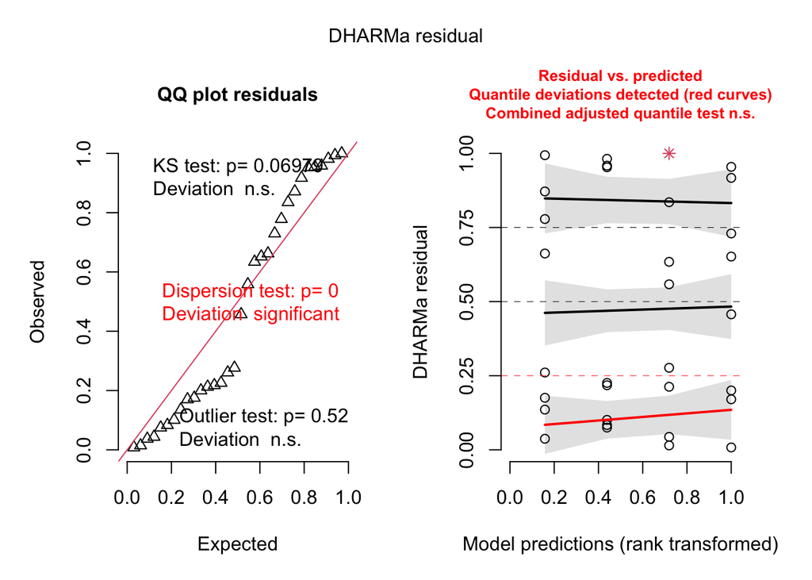

```r
mod.Baetidae.1 <- glm(Baetidae ~ Salinity * Flow,
                family = poisson(), data = df.mesocosms.nsed)

# residual plots with DHARMa package
simulationOutput <- simulateResiduals(fittedModel = mod.Baetidae.1, plot = F)
plot(simulationOutput)
```

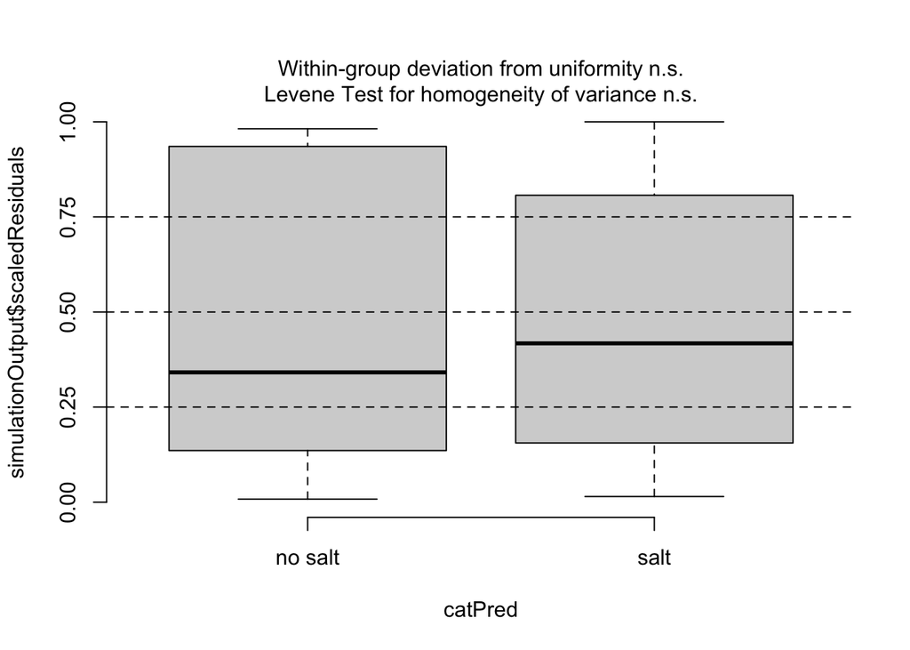

```r
plotResiduals(simulationOutput, form = df.mesocosms.nsed$Salinity)
```

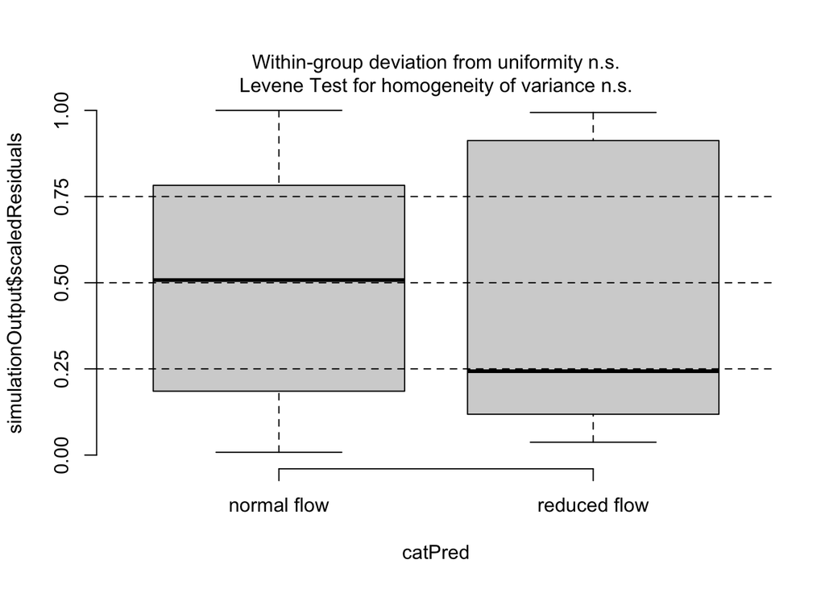

```r
plotResiduals(simulationOutput, form = df.mesocosms.nsed$Flow)
```

```r
# dispersion test
testDispersion(mod.Baetidae.1, plot = F)
```

```
##
##  DHARMa nonparametric dispersion test via sd of residuals fitted vs.
##  simulated
##
## data:  simulationOutput
## dispersion = 2.3607, p-value < 2.2e-16
## alternative hypothesis: two.sided
```

The DHARMa package creates residual plots which are easier to interpret than the standard residual plots you would have with a GLM. Here, both residual plots and the dispersion test indicate overdispersion: Ideally, we would expect all points in the QQ plot to fall along the diagonal line, but the S-shape indicates that residuals show a higher dispersion than expected for the Poisson distribution. This can be accounted for by using a negative binomial regression, instead. This can be specified in the *glmmTMB()* function (but not in *glm()*).

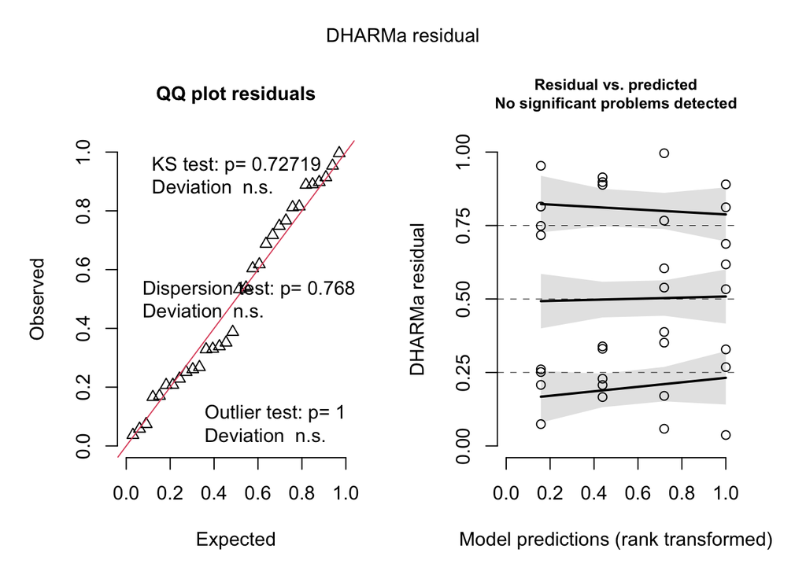

```r
mod.Baetidae.2 <- glmmTMB(Baetidae ~ Salinity * Flow,
                family = nbinom2(), data = df.mesocosms.nsed)

# residual plots with DHARMa package
simulationOutput <- simulateResiduals(fittedModel = mod.Baetidae.2, plot = F)
plot(simulationOutput)
```

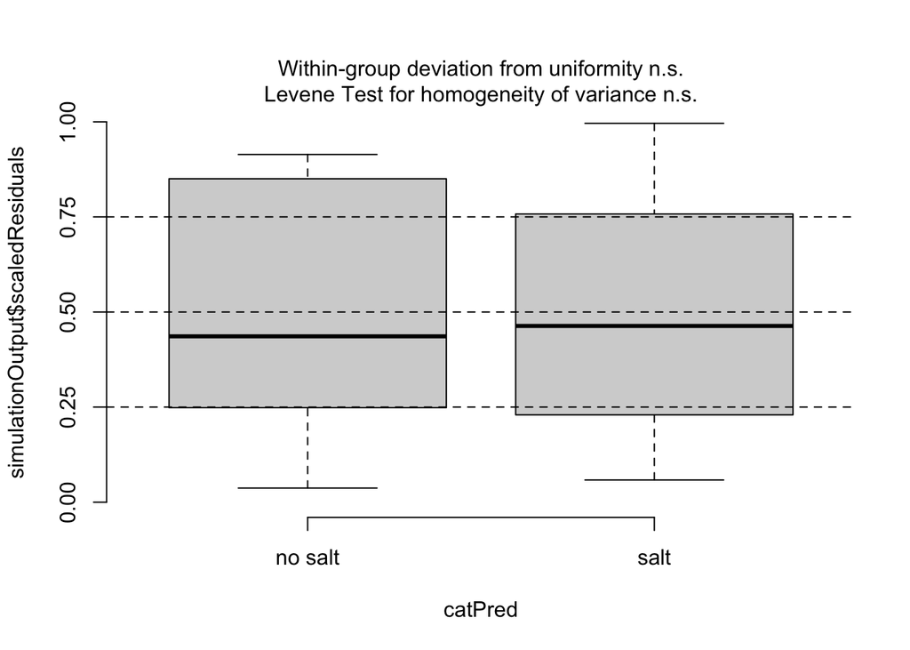

```r
plotResiduals(simulationOutput, form = df.mesocosms.nsed$Salinity)
```

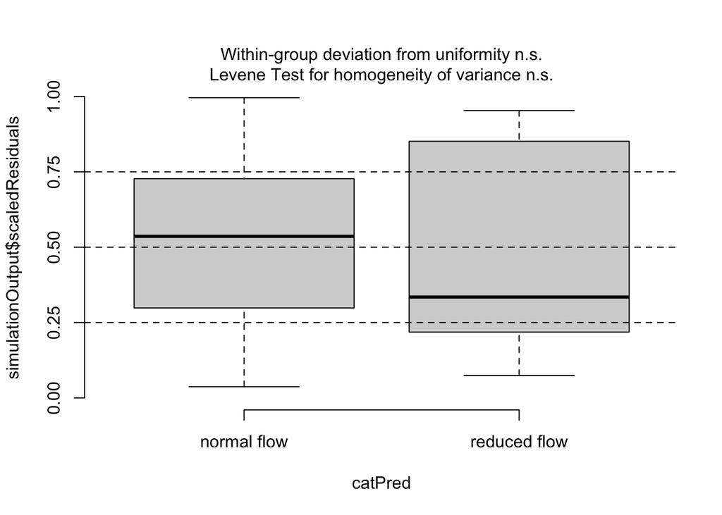

```r
plotResiduals(simulationOutput, form = df.mesocosms.nsed$Flow)
```

There are no obvious patterns in the residuals anymore and we can continue with model interpretation.

## Exercise 1

Can you reconstruct the regression equation based on the output from the *summary()* command? Try to manually calculate the model prediction for…

1. No stressor
2. Increased salinity
3. Reduced flow velocity
4. Increased salinity and reduced flow velocity

Important: Just like Poisson regression does, negative binomial regression uses a logarithmic link function. Remember to convert your results from the link scale to the response scale by exponentiation (*exp()*).

**Solution Exercise 1: Klick to expand**

```r
summary(mod.Baetidae.2)
```

```
##  Family: nbinom2  ( log )
## Formula:          Baetidae ~ Salinity * Flow
## Data: df.mesocosms.nsed
##
##      AIC      BIC   logLik deviance df.resid
##    212.1    219.5   -101.1    202.1       27
##
##
## Dispersion parameter for nbinom2 family (): 14.2
##
## Conditional model:
##                               Estimate Std. Error z value Pr(>|z|)
## (Intercept)                     3.0505     0.1214  25.133   <2e-16 ***
## Salinitysalt                   -0.1126     0.1737  -0.648   0.5167
## Flowreduced flow               -0.1954     0.1753  -1.115   0.2650
## Salinitysalt:Flowreduced flow  -0.4911     0.2611  -1.881   0.0599 .
## ---
## Signif. codes:  0 '***' 0.001 '**' 0.01 '*' 0.05 '.' 0.1 ' ' 1
```

```r
# formulate regression equation as function (you can also just do this on paper instead)
regeq <- function(salt, flow){

    # on link scale
    y.link = 3.0505 - 0.1126 * salt - 0.1954 * flow - 0.4911 * salt * flow

    # translate to response scale
    y = exp(y.link)

    return(y)
}
```

We can now calculate for different combinations of salt treatments (0 = stressor off, 1 = stressor on) and flow treatments what the regression model would predict.

```r
# What do we predict for control conditions (rounded to first decimal place)?
control <- regeq(0,0)
control # Abundance of 21.1 Baetid mayflies
```

```
## [1] 21.1259
```

```r
# What do we predict for reduced flow velocity?
red_flow <- regeq(0,1)
red_flow # Abundance of 17.4 Baetid mayflies
```

```
## [1] 17.37617
```

```r
# What do we predict for salt stessor only?
salt <- regeq(1,0)
salt # Abundance of 18.9 Baetid mayflies
```

```
## [1] 18.87616
```

```r
# What do we predict for both stressors?
red_flow.salt <- regeq(1,1)
red_flow.salt # Abundance of 9.5 Baetid mayflies
```

```
## [1] 9.501028
```

**Solution Exercise 1: Klick to expand**

```r
# predictions() function
mod.Baetidae.2.pred <- predictions(mod.Baetidae.2,
            # this creates predictions for all unique combinations of factors
            newdata = datagrid(FUN_factor = unique),
            # to supress a warning
            re.form = NA)

# select relevant columns. By conversion to a tibble, all columns are displayed in the printout
mod.Baetidae.2.pred |> select(Salinity, Flow, estimate) |> tibble()
```

```
## # A tibble: 4 × 3
##   Salinity Flow         estimate
##   <fct>    <fct>           <dbl>
## 1 no salt  reduced flow    17.4
## 2 no salt  normal flow     21.1
## 3 salt     reduced flow     9.50
## 4 salt     normal flow     18.9
```

The minor differences we can see are due to rounding.

## Exercise 2

Based on the single-stressor effects, what would be the expectation for…

1. The simple addition null model
2. Multiplicative null model
3. The dominance null model

Which of three null models is closest to the (modelled) joint stressor effect, which one is farthest?

Hint: Early in the lecture, you can find a formula for each of the null models.

**Solution exercise 2**

```r
##### Solution exercise 2 #####
simple.addition <- salt + red_flow - control
simple.addition
```

```
## [1] 15.12643
```

```r
multiplicative <- (salt * red_flow)/control
multiplicative
```

```
## [1] 15.52575
```

```r
dominance <- min(salt, red_flow)
dominance
```

```
## [1] 17.37617
```

```r
red_flow.salt
```

```
## [1] 9.501028
```

The simple addition null model is the closes to the predicitons, though not that far away from what the multiplicative null model predicts, while the dominance null model is farthest.

## Exercise 3

The *summary()* output for our regression model showed that the interaction term between salinity and reduced flow velocity was non-significant at the 5% alpha level. Which of the null models was statistically evaluated with this interaction term?

Instead, we would like to statistically evaluate the simple addition null model. We can do this in two ways: (1) We can change the link function. (2) We can use post-estimation inference.

We will start with changing the link function.

Re-fit the regression model, specifying nbinom2(link = “identity”) as distributional family. Use the *Anova()* function form the car-package to evaluate statistical significance for regression terms. Calculate model predictions for this refitted model (as above with the *predictions()* function for each treatment combination). What do you notive when taking a look at the predictions before?

Comment: The *Anova()* function would also allow you to evaluate the statistical significance of factor variables with more than one level (producing a single p-value for the factor variable instead of one for each comparison to the base level of the factor), and to interpret the statistical significance of main effects, if the interaction effect is non-significant. This last point cannot be done with the *summary()* command without refitting the model without interactions (and the p-values are then actually inaccurate, if you want to perform a confirmatory analysis; however, we won’t go into more detail here).

**Solution exercise 3**

```r
mod.Baetidae.2.identity <- glmmTMB(Baetidae ~ Salinity * Flow,
                            family = nbinom2(link = "identity"),
                            data = df.mesocosms.nsed)
Anova(mod.Baetidae.2.identity)
```

```
## Analysis of Deviance Table (Type II Wald chisquare tests)
##
## Response: Baetidae
##                 Chisq Df Pr(>Chisq)
## Salinity       7.8429  1  0.0051019 **
## Flow          11.3036  1  0.0007736 ***
## Salinity:Flow  1.6750  1  0.1955884
## ---
## Signif. codes:  0 '***' 0.001 '**' 0.01 '*' 0.05 '.' 0.1 ' ' 1
```

Also with the identity link, there is no significant deviation. Therefore, we have no evidence for an interaction between the two stressor for both null models tested here. We continue with generating the model predictions as we did above.

```r
mod.Baetidae.2.identity.pred <- predictions(mod.Baetidae.2.identity,
            newdata = datagrid(FUN_factor = unique),
            re.form = NA)
mod.Baetidae.2.identity.pred |> select(Salinity, Flow, estimate) |> as_tibble()
```

```
## # A tibble: 4 × 3
##   Salinity Flow         estimate
##   <fct>    <fct>           <dbl>
## 1 no salt  reduced flow    17.4
## 2 no salt  normal flow     21.1
## 3 salt     reduced flow     9.50
## 4 salt     normal flow     18.9
```

Comparing with the results from above, this is very much the same.

We continue with generating a conditional plot using the *ggplot()* function. If you haven’t used *ggplot()* before it might make sense to take a look at the associated cheat sheet to learn about how it is used: https://rstudio.github.io/cheatsheets/html/data-visualization.html

Plot the predictions as points (*geom_point()*) with Salinity on the x-axis and colored by flow velocity. Connect points with the same flow velocity condition with a straight line (*geom_line(group = Flow)*).

For the regression model with the logarithmic link, you should re-transform the estimate to the logarithmic scale for the conditional plot to reflect the multiplicative null model. Alternatively, you can use the *predictions()* function again, specifying type = “link” as argument.

**Solution Exercise 3**

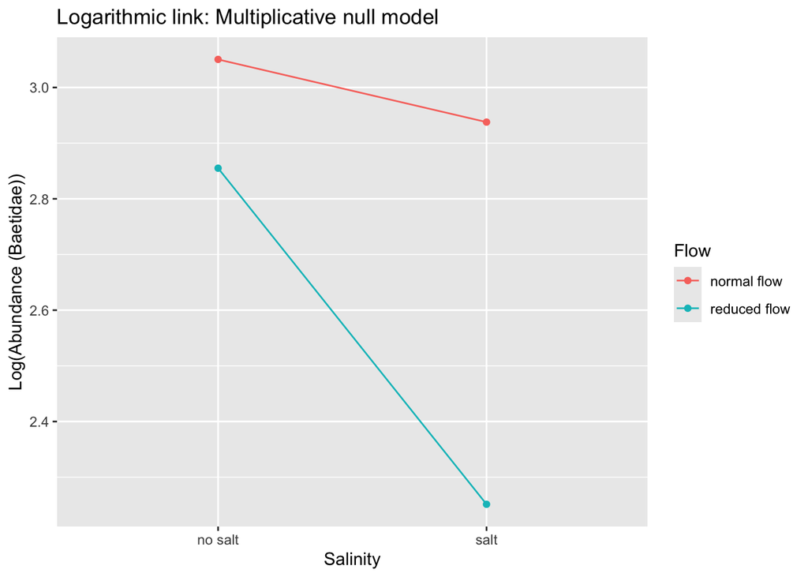

```r
mod.Baetidae.2.pred.link <- predictions(mod.Baetidae.2,
            newdata = datagrid(FUN_factor = unique),
            type = "link",
            re.form = NA)

# Logarithmic link
ggplot(data = mod.Baetidae.2.pred.link, aes(x = Salinity, y = estimate, color = Flow)) +
    geom_point() +
    # geom_line needs a group specification
    geom_line(aes(group = Flow)) +
    labs(y = "Log(Abundance (Baetidae))", title = "Logarithmic link: Multiplicative null model")
```

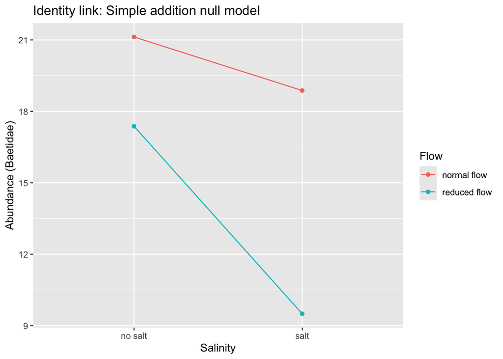

```r
# Identity link
ggplot(data = mod.Baetidae.2.identity.pred, aes(x = Salinity, y = estimate, color = Flow)) +
    geom_point() +
    geom_line(aes(group = Flow)) +
    labs(y = "Abundance (Baetidae)", title = "Identity link: Simple addition null model")
```

If our data would fit a null model perfectly, the differently colored lines should be parallel to each other.

## Exercise 4

We will now create a marginal effects plot for both regression models. For this, you can use the *slopes()* function from the **marginaleffects** package along with ggplot.

Using the *slopes()* function, calculate the marginal effect of flow reduction under salt conditions and under control conditions for salt. Make sure to do this on the link scale (type = “link”) - this will show us what the regression model evaluated with the interaction term. For the function with the identity link, the link scale is the same as the response scale, for other link functions, however, this is not the case.

Create a marginal effects plot for both regression models by plotting the effect of flow velocity in dependence of salt conditions.

**Solution exercise 4**

```r
marginal.effects.log <- slopes(mod.Baetidae.2,
                 # for which variable do you want to have the marginal effect?
                 variable = "Flow",
                 # which is the interacting variable?
                 by = "Salinity",
                 # on the link scale
                 type = "link",
                 # to surpress warnings
                 re.form=NA)
marginal.effects.log
```

```
##
##  Salinity Estimate Std. Error     z Pr(>|z|)    S  2.5 % 97.5 %
##   no salt   -0.195      0.175 -1.11    0.265  1.9 -0.539  0.148
##   salt      -0.687      0.193 -3.55   <0.001 11.3 -1.066 -0.307
##
## Term: Flow
## Type: link
## Comparison: reduced flow - normal flow
```

With the logarithmic link function, the marginal effects are log response ratios. We can translate to response ratios:

```r
marginal.effects.log |>
    mutate(response.ratio = exp(estimate)) |>
    select(Salinity, response.ratio) |>
    as_tibble()
```

```
## # A tibble: 2 × 2
##   Salinity response.ratio
##   <fct>             <dbl>
## 1 no salt           0.822
## 2 salt              0.503
```

So, given control conditions for salt, switching from normal to reduced flow velocity results in 82.2% of the Bateid mayflies remaining. With salt, only 50.3 % of the mayflies that are present with normal flow velocity are predicted to remain with reduced flow velocity.

```r
# marginal effects for identity link
marginal.effects.id <- slopes(mod.Baetidae.2.identity,
                variable = "Flow",
                by = "Salinity",
                type = "link",
                re.form = NA)
marginal.effects.id
```

```
##
##  Salinity Estimate Std. Error     z Pr(>|z|)    S 2.5 % 97.5 %
##   no salt    -3.75       3.38 -1.11    0.267  1.9 -10.4   2.87
##   salt       -9.37       2.74 -3.43   <0.001 10.7 -14.7  -4.01
##
## Term: Flow
## Type: link
## Comparison: reduced flow - normal flow
```

Now, create a marginal effects plot using ggplot. You can use *geom_hline()* to add a reference line for no effect. Add the confidence limits for the marginal effects estimates with *geom_errorbar()*.

**Solutions exercise 4**

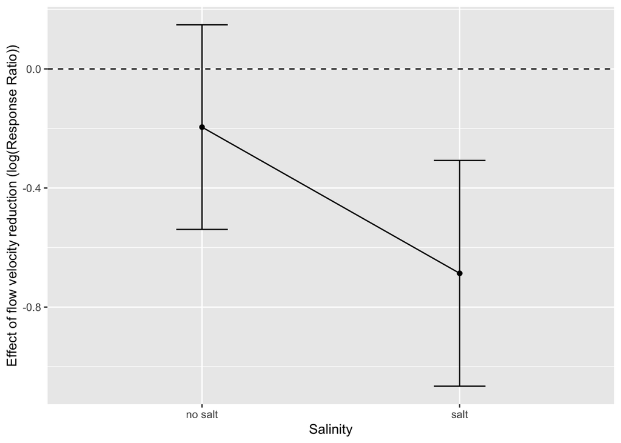

```r
# Marginal effects plot on link scale
ggplot(marginal.effects.log, aes(x = Salinity, y = estimate)) +
    geom_point() +
    geom_line(group = c(1,1)) +
    geom_hline(yintercept = 0, linetype = "dashed") +
    geom_errorbar(aes(ymin = conf.low, ymax = conf.high), width = 0.2) +
    labs(y = "Effect of flow velocity reduction (log(Response Ratio))")
```

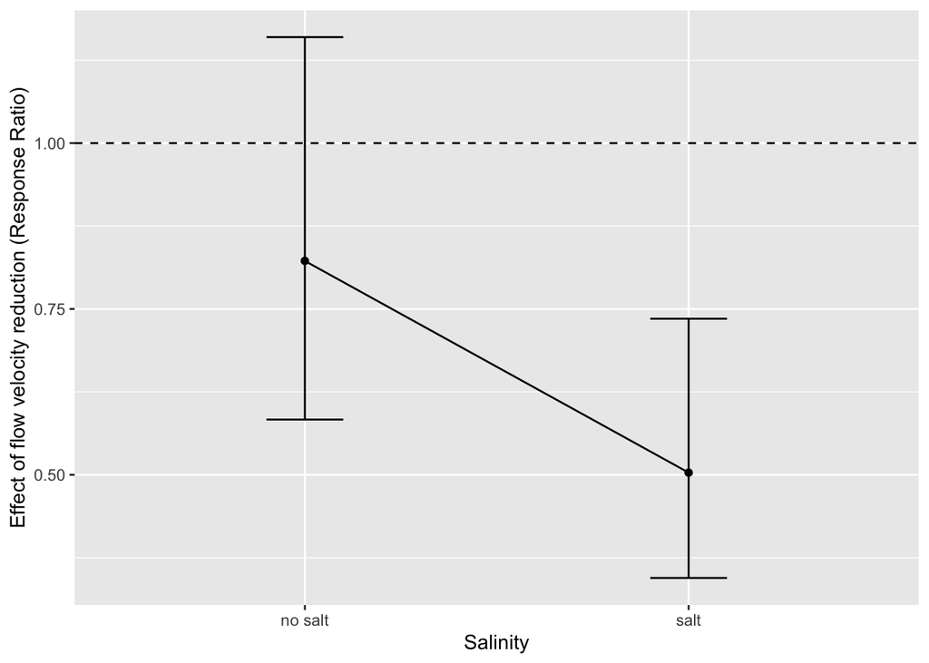

```r
# We can also translate to response ratios (Treatment/Control) by exponentiating the estimate
# Then, 1 would refer to no effect instead of 0
ggplot(marginal.effects.log, aes(x = Salinity, y = exp(estimate))) +
    geom_point() +
    geom_line(group = c(1,1)) +
    geom_hline(yintercept = 1, linetype = "dashed") +
    geom_errorbar(aes(ymin = exp(conf.low), ymax = exp(conf.high)), width = 0.2) +
    labs(y = "Effect of flow velocity reduction (Response Ratio)")
```

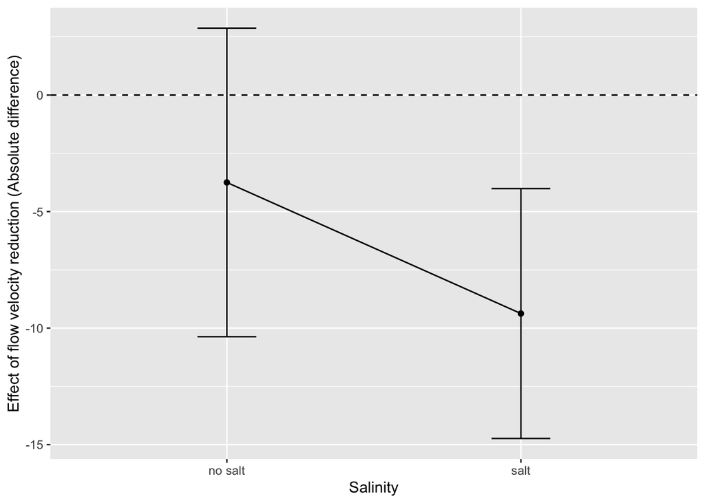

```r
# Marginal effects plot on link scale for identity link
ggplot(marginal.effects.id, aes(x = Salinity, y = estimate)) +
    geom_point() +
    geom_line(group = c(1,1)) +
    geom_errorbar(aes(ymin = conf.low, ymax = conf.high), width = 0.2) +
    geom_hline(yintercept = 0, linetype = "dashed") +
    labs(y = "Effect of flow velocity reduction (Absolute difference)")
```

## Exercise 5

In fact, the *slopes()* function can also be used as a direct way to test the simple addition null model when the logarithmic link function has been used. This is the more robust approach compared to changing from the canonical logarithmic link function to the non-canonical identity link, which can sometimes cause failure for model fitting and will result in inaccurate confidence intervals for count data. What you need to do in this case is:

1. Change from scale = “link” to scale = “response”. Now, the slope of the line connecting model predictions on the response scale is estimated instead of the link scale.

**Solution exercise 6**

```r
slopes(mod.Baetidae.2,
       variable = "Flow",
       by = "Salinity",
       # change to response scale
       type = "response",
       re.form = NA)
```

```
##
##  Salinity Estimate Std. Error     z Pr(>|z|)    S 2.5 % 97.5 %
##   no salt    -3.75       3.38 -1.11    0.267  1.9 -10.4   2.87
##   salt       -9.37       2.74 -3.43   <0.001 10.7 -14.7  -4.01
##
## Term: Flow
## Type: response
## Comparison: reduced flow - normal flow
```

This shows that a reduction in flow velocity results in a loss of 3.75 individuals given no salt conditions, but in a loss of 9.37 individuals given salt conditions.

2. Specify a hypothesis. We can do this in various ways, e.g., by writing: hypothesis = “b2 - b1 = 0”. This estimates how much larger (or smaller, if negative) the slope is under salt conditions (the second row of the *slopes()* output, therefore b2) compared to no salt conditions (first row of the output, b1). Compare also with the statistical results from the ANOVA output from the identity link function.

**Solution exercise 5**

```r
slopes.simple.addition <- slopes(mod.Baetidae.2,
       variable = "Flow",
       by = "Salinity",
       type = "response",
       re.form = NA,
       hypothesis = "b2 - b1 = 0")
slopes.simple.addition
```

```
##
##  Hypothesis Estimate Std. Error     z Pr(>|z|)   S 2.5 % 97.5 %
##     b2-b1=0    -5.62       4.35 -1.29    0.196 2.4 -14.1   2.89
##
## Type: response
```

This shows that with the second stressor (salinity) being present, too, 5.62 individuals more are lost due to reduced flow velocity compared to the single stressor effect of reduced flow velocity. However, the p-value indicates that this is far from being statistically significant.

```r
Anova(mod.Baetidae.2.identity)
```

```
## Analysis of Deviance Table (Type II Wald chisquare tests)
##
## Response: Baetidae
##                 Chisq Df Pr(>Chisq)
## Salinity       7.8429  1  0.0051019 **
## Flow          11.3036  1  0.0007736 ***
## Salinity:Flow  1.6750  1  0.1955884
## ---
## Signif. codes:  0 '***' 0.001 '**' 0.01 '*' 0.05 '.' 0.1 ' ' 1
```

The statistical conclusion and even the p-values are (almost) identical between the two approaches here. This is often the case if we have only factorial predictors.

## Exercise 6

**Solution exercise 6**

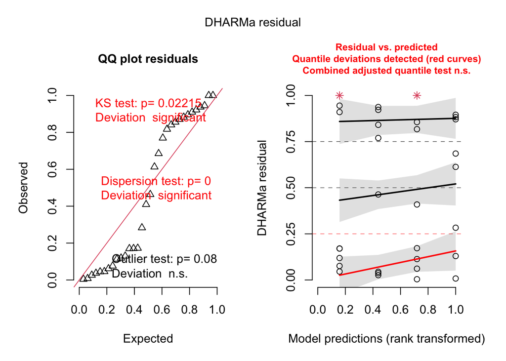

```r
df.mesocosms.nsalt <- df.mesocosms |> filter(Salinity == "no salt")

# fit regression model
mod.heptageniidae <- glm(Heptageniidae ~ Sediment * Flow, data = df.mesocosms.nsalt,
                          family = poisson())

# residual diagnostics
simulationOutput <- simulateResiduals(fittedModel = mod.heptageniidae, plot = F)
plot(simulationOutput)
```

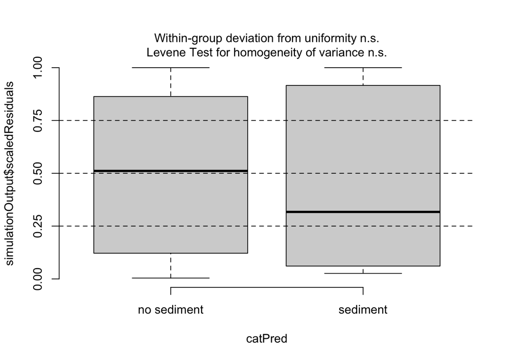

```r
plotResiduals(simulationOutput, form = df.mesocosms.nsalt$Sediment)
```

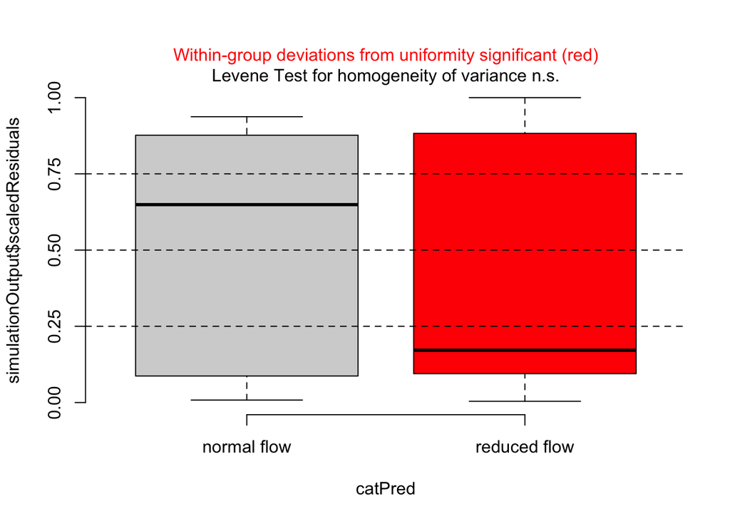

```r
plotResiduals(simulationOutput, form = df.mesocosms.nsalt$Flow)
```

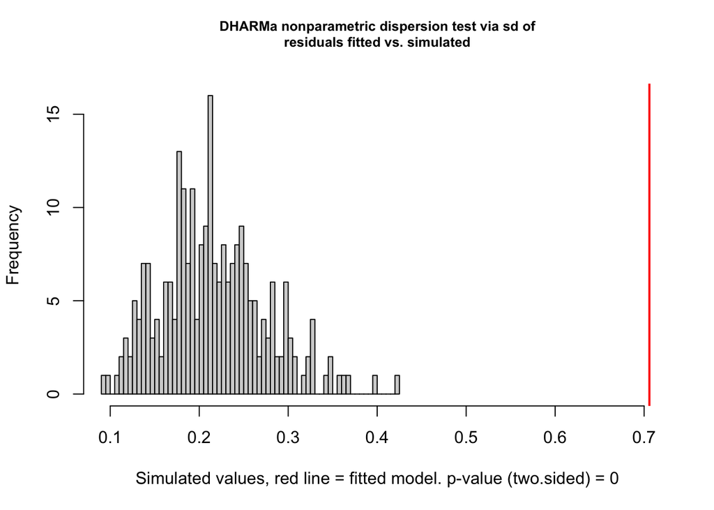

```
##
##  DHARMa nonparametric dispersion test via sd of residuals fitted vs.
##  simulated
##
## data:  simulationOutput
## dispersion = 3.2776, p-value < 2.2e-16
## alternative hypothesis: two.sided
```

```r
testDispersion(mod.heptageniidae)
```

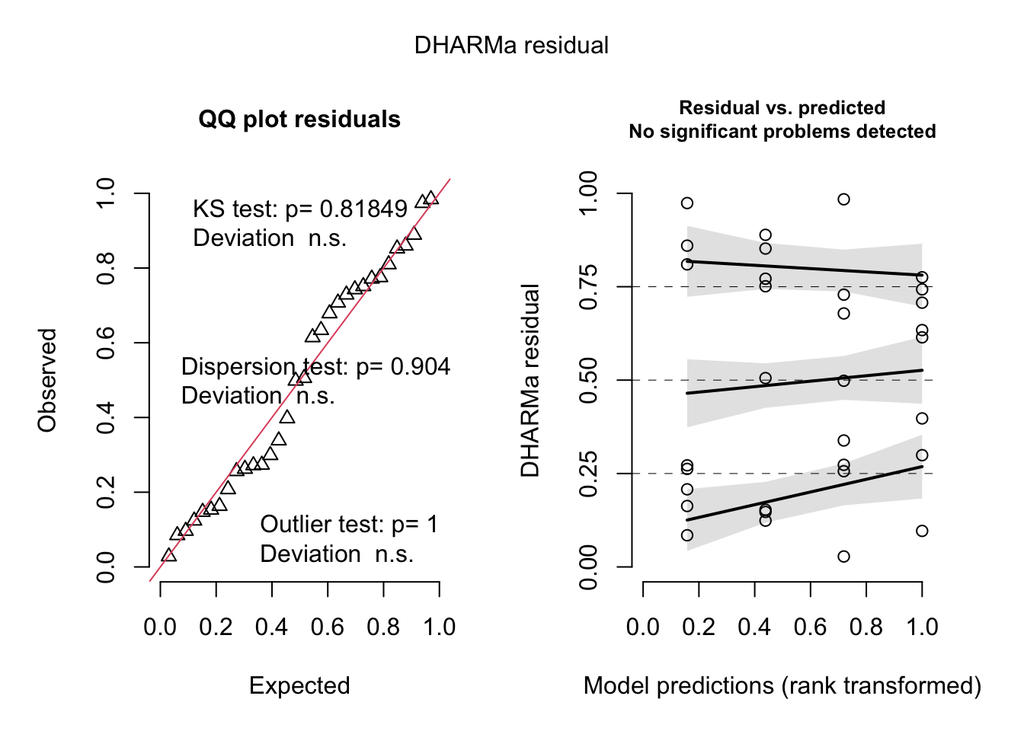

```r
# change to negative binomial model
mod.heptageniidae.nb <- glmmTMB(Heptageniidae ~ Sediment * Flow, data = df.mesocosms.nsalt,
                          family = nbinom2())

# residual diagnostics
simulationOutput <- simulateResiduals(fittedModel = mod.heptageniidae.nb, plot = F)
plot(simulationOutput)
```

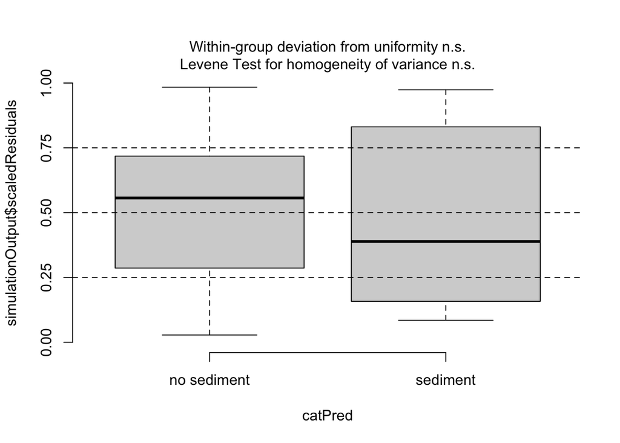

```r
plotResiduals(simulationOutput, form = df.mesocosms.nsalt$Sediment)
```

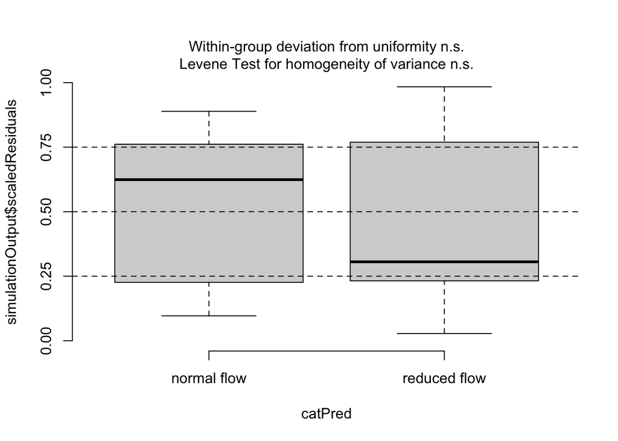

```r
plotResiduals(simulationOutput, form = df.mesocosms.nsalt$Flow)
```

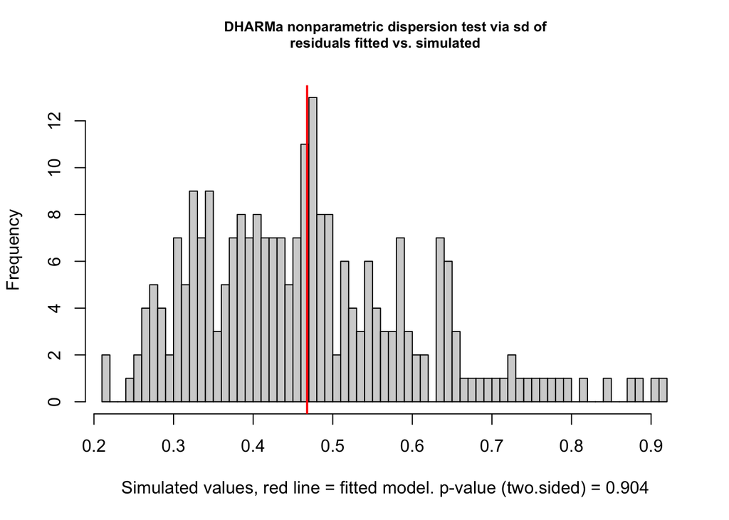

```
##
##  DHARMa nonparametric dispersion test via sd of residuals fitted vs.
##  simulated
##
## data:  simulationOutput
## dispersion = 0.99903, p-value = 0.904
## alternative hypothesis: two.sided
```

```r
testDispersion(mod.heptageniidae.nb)
```

Interpret the *Anova()* output concerning the multiplicative null model. Then, use the slopes() function to test the simple addition null model.

**Solution exercise 6**

```r
# Anova for multiplicative null model
Anova(mod.heptageniidae.nb)
```

```
## Analysis of Deviance Table (Type II Wald chisquare tests)
##
## Response: Heptageniidae
##                 Chisq Df Pr(>Chisq)
## Sediment      31.0244  1  2.548e-08 ***
## Flow          11.4343  1   0.000721 ***
## Sediment:Flow  7.7927  1   0.005246 **
## ---
## Signif. codes:  0 '***' 0.001 '**' 0.01 '*' 0.05 '.' 0.1 ' ' 1
```

The data show evidence for a deviation from the multiplicative null model.

```r
# slopes for testing additive null model
mod.heptageniidae.nb.slopes <- slopes(mod.heptageniidae.nb,
       variable = "Sediment",
       by = "Flow",
       type = "response",
       re.form = NA)
mod.heptageniidae.nb.slopes
```

```
##
##          Flow Estimate Std. Error     z Pr(>|z|)    S 2.5 % 97.5 %
##  normal flow     -12.6       5.75 -2.20   0.0281  5.2 -23.9  -1.35
##  reduced flow    -24.9       4.65 -5.34   <0.001 23.4 -34.0 -15.75
##
## Term: Sediment
## Type: response
## Comparison: sediment - no sediment
```

```r
# test additive null model
slopes(mod.heptageniidae.nb,
       variable = "Sediment",
       by = "Flow",
       type = "response",
       re.form = NA,
       hypothesis = "b2 -  b1 = 0")
```

```
##
##  Hypothesis Estimate Std. Error     z Pr(>|z|)   S 2.5 % 97.5 %
##     b2-b1=0    -12.3        7.4 -1.66   0.0978 3.4 -26.8   2.25
##
## Type: response
```

There is no statistically significant deviation from the simple addition null model.

Finally, create a marginal effects plot for each of the two null models.

**Solution exercise 6**

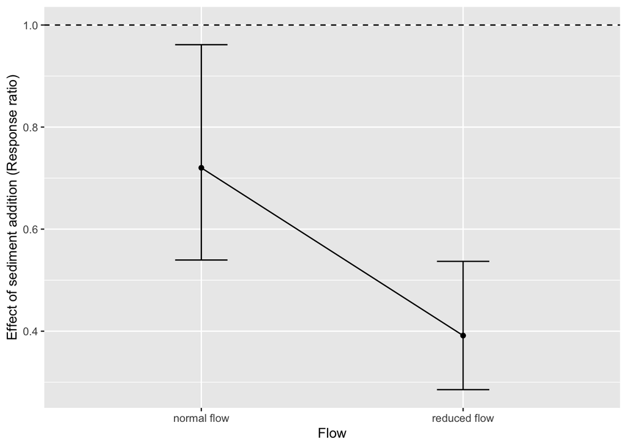

```r
# slopes for multiplicative null model for marginal effects plots
mod.heptageniidae.nb.slopes.link <- slopes(mod.heptageniidae.nb,
       variable = "Sediment",
       by = "Flow",
       type = "link",
       re.form = NA)

# Multiplicative null model
ggplot(data = mod.heptageniidae.nb.slopes.link, aes(x = Flow, y = exp(estimate))) +
    geom_point() +
    geom_line(group = c(1,1)) +
    geom_hline(yintercept = 1, linetype = "dashed") +
    labs(y = "Effect of sediment addition (Response ratio)") +
    geom_errorbar(aes(ymin = exp(conf.low), ymax = exp(conf.high)), width = 0.2)
```

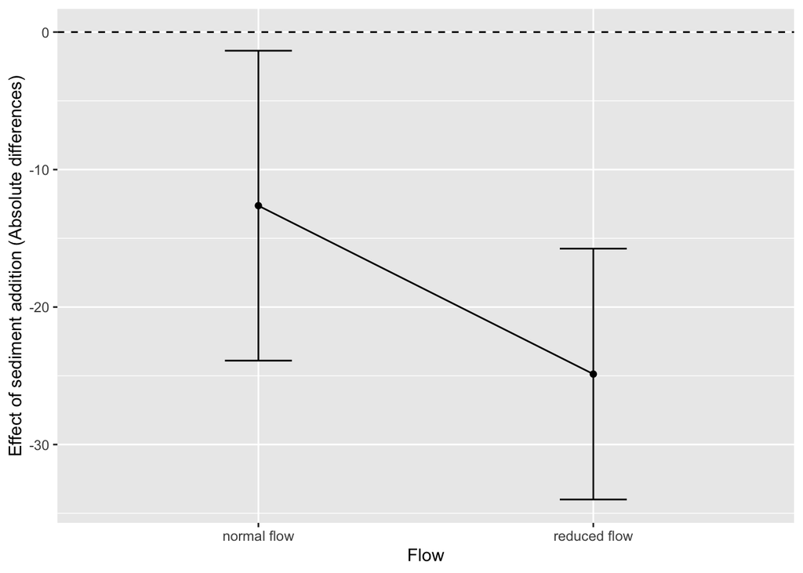

```r
# Simple addition null model
ggplot(data = mod.heptageniidae.nb.slopes, aes(x = Flow, y = estimate)) +
    geom_point() +
    geom_line(group = c(1,1)) +
    geom_hline(yintercept = 0, linetype = "dashed") +
    labs(y = "Effect of sediment addition (Absolute differences)") +
    geom_errorbar(aes(ymin = conf.low, ymax = conf.high), width = 0.2)
```

# Bonus section. Case study 2: factor-gradient interactions

Lastly, we will take a look at a combination of a stressor gradient and a factorial stressor. For this, we will use a simulated dataset. First, take a look at its structure. Two predictors can be used: Temperature as a stressor gradient (in °C) and Fungicide as an on-off stressor. The response is survival rate of an exposed organism (e.g. mayfly larvae).

```r
head(df.simulated)
```

```
## # A tibble: 6 × 5
##   Temperature Fungicide Survival n_start survival_rate
##         <dbl> <chr>        <dbl>   <dbl>         <dbl>
## 1        10   No              10      10           1
## 2        10.5 No               9      10           0.9
## 3        11   No              10      10           1
## 4        11.5 No               8      10           0.8
## 5        12   No               9      10           0.9
## 6        12.5 No              10      10           1
```

## Exercise 7

Fit a binomial regression. You can use survival_rate as response, and you need to specify n_start as the *weights* argument in the regression model.

Try to change the link function from the default canonical link (“logit”) to an identity link. For this to run at all, you will need to specify starting values. Try: start = c(0.9, 0, 0, 0). What do you notice?

**Solution exercise 7**

```r
# code character variable as factor
df.simulated$Fungicide <- factor(df.simulated$Fungicide)

# fit binomial regression model with canonical link function (logit)
mod.simulated.logit <- glm(survival_rate ~ Temperature * Fungicide,
                       family = binomial(),
                       weights = n_start,
                       data = df.simulated)

# fit binomial regression model with identity link function
mod.simulated.id <- glm(survival_rate ~ Temperature * Fungicide,
                    family = binomial(link = "identity"),
                    weights = n_start,
                    data = df.simulated,
                    start = c(0.9, 0,0,0))
```

[output not shown]

```
## Warning: glm.fit: algorithm did not converge
```

```
## Warning: glm.fit: algorithm stopped at boundary value
```

```
## Warning: glm.fit: fitted probabilities numerically 0 or 1 occurred
```

The regression model with the identity link function gives a lot of warnings and fails to converge, i.e., it could not find an optimal solution.

Create a conditional plot for both regression models.

**Solution exercise 7**

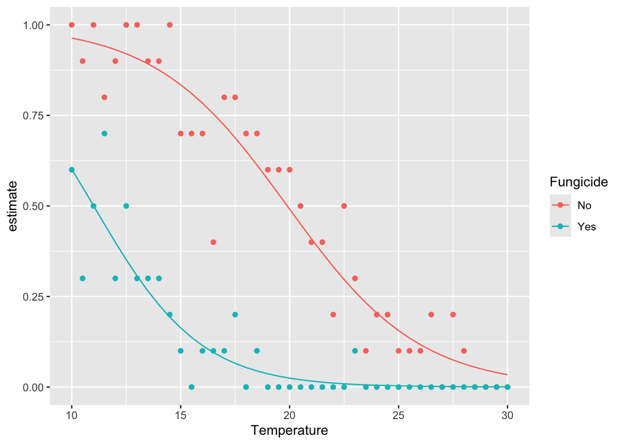

```r
pred.simulated.logit <- predictions(mod.simulated.logit, type = "response")
pred.simulated.id <- predictions(mod.simulated.id, type = "response")

ggplot(data = pred.simulated.logit, aes(x = Temperature, y = estimate, color = Fungicide)) +
    geom_line(aes(group = Fungicide)) +
    geom_point(data = df.simulated, aes(y = survival_rate))
```

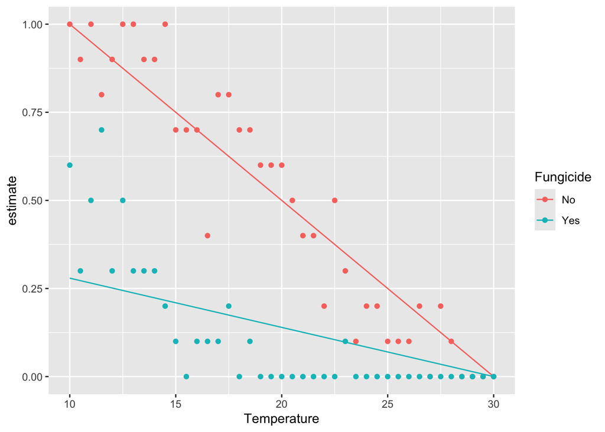

```r
ggplot(data = pred.simulated.id, aes(x = Temperature, y = estimate, color = Fungicide)) +
    geom_line(aes(group = Fungicide)) +
    geom_point(data = df.simulated, aes(y = survival_rate))
```

Clearly, the identity link is terrible in following the pattern of the data. The logit link does much better and the data points spread randomly along the fitted regression lines.

## Exercise 8

Only the regression with the canonical link function converged successfully and makes good predictions. Thus, we should not use a different link function to test the simple addition null model. What we can do instead is using the *slopes()* function.

For this, first create a datagrid with all combinations of observed temperature and fungicide values. Use the *slopes()* function to get the marginal effect of temperature on the response scale across these observations. Now, plot this marginal effect with temperature on the x axis and colored by the fungicide condition. What does this plot show? Compare with the model predictions plotted above.

**Solution exercise 7**

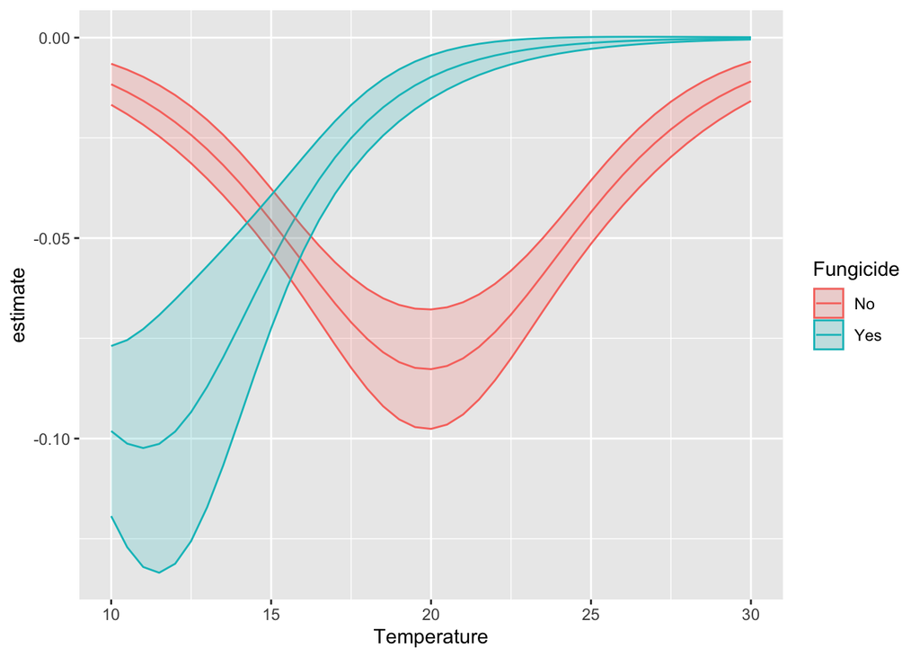

```r
newdata <- datagrid(model = mod.simulated.logit,
                    Temperature = unique,
                    Fungicide = unique)

marginal_effects_temperature <- slopes(mod.simulated.logit,
       variable = "Temperature",
       newdata = newdata,
       type = "response")

ggplot(marginal_effects_temperature, aes(x = Temperature, y = estimate, color = Fungicide)) +
    geom_line(aes(group = Fungicide)) +
    geom_ribbon(aes(ymin = conf.low, ymax = conf.high, fill = Fungicide), alpha = 0.2)
```

This shows the slope of the fitted regression model: For control conditions (no fungicide) it becomes more and more negative until 20°C and then the slope still stays negative, but becomes closer and closer to 0. If the fungicide is present, the slope almost starts at its strongest angle and the becomes flatter with higher temperatures. If the simple addition null model was true, the slope should be identical and the red and blue line should overlap.

## Exercise 9

Theoretically, we could for each temperature calculate the difference in slope between the two fungicide conditions. This would represent the deviation from the simple addition null model. However, this is difficult to code and for now all we do is:

1. Calculating the average slope across all observed temperatures within No fungicide and Fungicide conditions.
2. Calculate the difference between those average slopes.

This is what we will use to infer if we have a deviation from the simple addition null model across our observations.

**Solution exercise 9**

```r
# Take a look at the output before adding the hypothesis
slopes(mod.simulated.logit,
       variable = "Temperature",
       newdata = newdata,
       type = "response",
       by = "Fungicide")
```

```
##
##  Fungicide Estimate Std. Error      z Pr(>|z|)    S   2.5 %  97.5 %
##        No   -0.0456   0.000958 -47.59   <0.001  Inf -0.0475 -0.0437
##        Yes  -0.0305   0.003376  -9.04   <0.001 62.5 -0.0371 -0.0239
##
## Term: Temperature
## Type: response
## Comparison: dY/dX
```

```r
# testing of null model
slopes(mod.simulated.logit,
       variable = "Temperature",
       newdata = newdata,
       type = "response",
       by = "Fungicide",
       hypothesis = "b2 - b1 = 0")
```

```
##
##  Hypothesis Estimate Std. Error   z Pr(>|z|)    S  2.5 % 97.5 %
##     b2-b1=0   0.0151    0.00351 4.3   <0.001 15.8 0.0082  0.022
##
## Type: response
```

For combining two gradients or when testing the multiplicative null model with this approach, coding with the marginaleffects package becomes less straight-forward. If you are interested in learning more about how to test the simple addition null model, the multiplicative null model or the dominance null model also in these situations, you can take a look at our preprint (DOI: 10.22541/au.174480136.61924343/v1), which also provides custom-made R functions which should facilitate the process of null model testing for different experimental designs.

# Further reading

Arel-Bundock V, Greifer N, Heiss A (2024). “How to Interpret Statistical Models Using marginaleffects for R and Python.” Journal of Statistical Software, 111(9), 1-32. doi:10.18637/jss.v111.i09 https://doi.org/10.18637/jss.v111.i09.

(and the online book: https://marginaleffects.com/)

Duncan, R. P., & Kefford, B. J. (2021). Interactions in statistical models: Three things to know. Methods in Ecology and Evolution, 12, 2287–2297.

Jarvis, L., Rosenfeld, J., Gonzalez-Espinosa, P. C., & Enders, E. C. (2024). A process framework for integrating stressor-response functions into cumulative effects models. Science of The Total Environment, 906, 167456.

Madge Pimentel, I., Albini, D., Beermann, A., Leese, F., Macaulay, S., Matthaei, C., … & Schäfer, R. (2025). Hypothesis-Driven Research on Multiple Stressors: An Analytical Framework for Stressor Interactions. DOI: 10.22541/au.174480136.61924343/v1

Schäfer, R. B., & Piggott, J. J. (2018). Advancing understanding and prediction in multiple stressor research through a mechanistic basis for null models. Global Change Biology, 24, 1817–1826.

Spake, R., Bowler, D. E., Callaghan, C. T., Blowes, S. A., Doncaster, C. P., Antão, L. H., Nakagawa, S., McElreath, R., & Chase, J. M. (2023). Understanding ‘it depends’ in ecology: A guide to hypothesising, visualising and interpreting statistical interactions. Biological Reviews, brv.12939.

Vinebrooke, R. D., Cottingham, K. L., Scheffer, J. N., Marten, Dodson, S. I., Maberly, S. C., & Sommer, U. (2004). Impacts of multiple stressors on biodiversity and ecosystem functioning: The role of species co-tolerance. Oikos, 104, 451–457.